# Screen Quality Control (Mouse)

Jan Sauer

22.10.2017

This vignette performs quality control of the mouse screen.

# 1 Data preprocessing

The data preprocessing consists of the following steps:

- Separate objects into “organoids” (area >= 2500 pixels) and “shrapnel” (area <= 2500 pixels).
- Calculate the summary features for each of these categories of objects within a well (median / mad).
- I decided for this summary statistic as some features may only have features within a certain range, e.g. [0, 1] for the asphericity. Even under the assumption of normally distributed variation within a well, this limitation would cause the mean to skew the summary statistic towards the middle of the interval.
- Subtract from each feature the median of the DMSO wells and divide by their standard deviation on each plate to eliminate batch effects.
- Combine plates belonging to a single cell line and calculate the z-score for each feature.

This is done in an external python script. The data and all intermediate steps are stored in the corresponding hdf5 files in the PROMISE features directory.

```r
cell_lines = unique(substr(list.files(feature_dir, pattern = "M001"), 1, 7))
features = setNames(
  object = vector(mode="list", length=length(cell_lines)),
  nm = cell_lines)
features_metadata = setNames(
  object = vector(mode="list", length=length(cell_lines)),
  nm = cell_lines)
for(cell_line in cell_lines) {
  cl_feature_fn = file.path(feature_dir, sprintf("%s_averaged_features_%s.h5", cell_line, feature_type))
  features[[cell_line]] = data.frame(h5read(cl_feature_fn, hdf5_dataset))
  colnames(features[[cell_line]]) = h5read(cl_feature_fn, "feature_names")
  rownames(features[[cell_line]]) = h5read(cl_feature_fn, "well_names")

  features_metadata[[cell_line]] = data.frame(
    "REPLICATE" = h5read(cl_feature_fn, "replicates"),
    "CONCENTRATION" = h5read(cl_feature_fn, "concentrations"),
    "DRUG" = h5read(cl_feature_fn, "drugs"),
    row.names = rownames(features[[cell_line]]))
}
features = do.call(rbind, features)
rownames(features) = sapply(strsplit(rownames(features), ".", fixed = TRUE), "[[", 2)
features_metadata = do.call(rbind, features_metadata)
rownames(features_metadata) = sapply(strsplit(rownames(features_metadata), ".", fixed = TRUE), "[[", 2)
```

For any number of reasons, some wells may not have been processed properly. In particular, if there is no information to the total number of organoids in a well then it can be safely discarded as this feature should always be computable.

```r
na_rows = rownames(features)[!is.finite(features$organoids_num.of.objects)]
na_rows_repid = paste0(substr(na_rows, 1, 7), "_", substr(na_rows, 12, 19))
all_wells_repid = paste0(substr(rownames(features), 1, 7), "_", substr(rownames(features), 12, 19))
features = features[!all_wells_repid %in% na_rows_repid, ]
features_metadata = features_metadata[!all_wells_repid %in% na_rows_repid, ]
```

Due to the normalization method, features may be marked as NaN or Infinity. This can happen in particular if a feature was constant across all DMSO wells of a plate. Since the wells are already averages over all organoids within the wells, I assume that a constant feature value across all DMSO wells indicates a bad feature. As I’ve already removed any bad wells, I now remove all features that do not have finite values in all remaining wells.

```r
nanfeatures = colSums(!is.finite(as.matrix(features)))
features = features[,nanfeatures == 0]
```

The features should now all be finite

```r
cat("Number of NaN features:", sum(!is.finite(as.matrix(features))))
```

```
## Number of NaN features: 0
```

Lastly, some of the wells were found to be entirely blurry and are effectively unusable. These have been previously classified with a random forest classifier. The blurry wells and their replicates are filtered out.

```r
blurry_wells = read.table("blurry_wells_mouse.txt", stringsAsFactors = FALSE)
blurry_wells_repid = paste0(substr(blurry_wells$V1, 1, 7), "_", substr(blurry_wells$V1, 12, 19))
all_wells_repid = paste0(substr(rownames(features), 1, 7), "_", substr(rownames(features), 12, 19))
wells_to_keep = !all_wells_repid %in% blurry_wells_repid
features = features[wells_to_keep,]
features_metadata = features_metadata[wells_to_keep,]
```

# 2 Quality Control

## 2.1 Cell Line Quality

Normally, one would look at the z-factor, a degree of separation between positive and negative controls, for each feature to determine the assay quality. As there are no known positive controls for the mouse screen, I instead look at the z-factor for all treatments compared to the negative controls (DMSO) for a few characteristic features, the number of organoids, the total biomass, and the average organoid size. I expect that at least some of the treatments should show considerable differences to the DMSO controls in these features.

The z-factor is defined as:

$$Z^\prime = 1 - \frac{3 \cdot (\sigma_{treatment} + \sigma_{DMSO})}{|\mu_{treatment} - \mu_{DMSO}|}$$

```r
treatments = unique(features_metadata$DRUG)

all_biomass_zprime = list()
all_orgsize_zprime = list()
all_orgnum_zprime = list()

for(cell_line in cell_lines) {
  biomass_zprime = setNames(
    object = vector(mode="numeric", length=length(treatments)),
    nm = treatments)
  orgsize_zprime = setNames(
    object = vector(mode="numeric", length=length(treatments)),
    nm = treatments)
  orgnum_zprime = setNames(
    object = vector(mode="numeric", length=length(treatments)),
    nm = treatments)
  dmso_treatment_biomass = features[
      features_metadata$DRUG == "DMSO" &
        substr(rownames(features), 1, 7) == cell_line,
      "Total.Biomass"]
  dmso_treatment_orgsize = features[
      features_metadata$DRUG == "DMSO" &
        substr(rownames(features), 1, 7) == cell_line,
      "organoids_x.0.s.area_expected"]
  dmso_treatment_orgnum = features[
      features_metadata$DRUG == "DMSO" &
        substr(rownames(features), 1, 7) == cell_line,
      "organoids_num.of.objects"]
  for(treatment in treatments) {
    biomass_treatment_feat = features[
      features_metadata$DRUG == treatment &
        substr(rownames(features), 1, 7) == cell_line,
      "Total.Biomass"]
    orgsize_treatment_feat = features[
      features_metadata$DRUG == treatment &
        substr(rownames(features), 1, 7) == cell_line,
      "organoids_x.0.s.area_expected"]
    orgnum_treatment_feat = features[
      features_metadata$DRUG == treatment &
        substr(rownames(features), 1, 7) == cell_line,
      "organoids_num.of.objects"]

    biomass_zprime[[treatment]] = imageHTS::zprime(
      dmso_treatment_biomass,  biomass_treatment_feat, method = "robust")
    orgsize_zprime[[treatment]] = imageHTS::zprime(
      dmso_treatment_orgsize,  orgsize_treatment_feat, method = "robust")
    orgnum_zprime[[treatment]] = imageHTS::zprime(
      dmso_treatment_orgnum,  orgnum_treatment_feat, method = "robust")
  }

  all_biomass_zprime[[cell_line]] = biomass_zprime
  all_orgsize_zprime[[cell_line]] = orgsize_zprime
  all_orgnum_zprime[[cell_line]] = orgnum_zprime
}
```

```
## No methods found in "RSQLite" for requests: dbGetQuery
```

```r
all_biomass_zprime_df = do.call(cbind, all_biomass_zprime)
all_biomass_zprime_df = all_biomass_zprime_df[
  rowSums(!is.finite(as.matrix(all_biomass_zprime_df))) ==  0,]
all_biomass_zprime_df = apply(all_biomass_zprime_df, 2, sort)
all_biomass_zprime_df = melt(all_biomass_zprime_df)
all_orgsize_zprime_df = do.call(cbind, all_orgsize_zprime)
all_orgsize_zprime_df = all_orgsize_zprime_df[
  rowSums(!is.finite(as.matrix(all_orgsize_zprime_df))) ==  0,]
all_orgsize_zprime_df = apply(all_orgsize_zprime_df, 2, sort)
all_orgsize_zprime_df = melt(all_orgsize_zprime_df)
all_orgnum_zprime_df = do.call(cbind, all_orgnum_zprime)
all_orgnum_zprime_df = all_orgnum_zprime_df[
  rowSums(!is.finite(as.matrix(all_orgnum_zprime_df))) ==  0,]
all_orgnum_zprime_df = apply(all_orgnum_zprime_df, 2, sort)
all_orgnum_zprime_df = melt(all_orgnum_zprime_df)

ggplotdf = data.frame(
  "Cell.Line" = all_biomass_zprime_df$Var2,
  "Total.Biomass" = all_biomass_zprime_df$value,
  "Num.Organoids" = all_orgnum_zprime_df$value,
  "Avg.Organoid.Size" = all_orgsize_zprime_df$value,
  "Treatment" = NA_real_)
ggplotdf = ggplotdf[
  is.finite(ggplotdf$Total.Biomass) &
  is.finite(ggplotdf$Num.Organoids) &
  is.finite(ggplotdf$Avg.Organoid.Size), ]
for(cell_line in cell_lines) {
  ggplotdf[ggplotdf$Cell.Line == cell_line, "Treatment"] =
    seq_len(table(ggplotdf$Cell.Line)[cell_line])
}
```

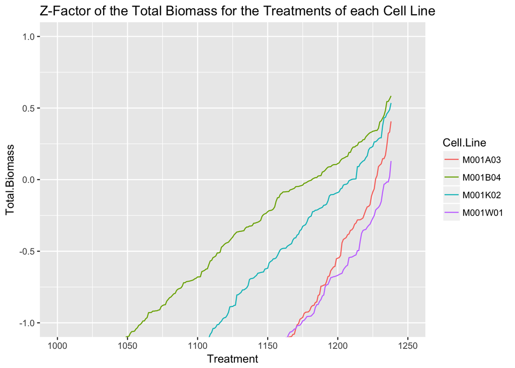

```r
ggplot(data = ggplotdf) +
  geom_line(aes(x = Treatment, y = Total.Biomass, color = Cell.Line)) +
  coord_cartesian(ylim = c(-1, 1), xlim = c(1000, 1250)) +
  ggtitle(label = "Z-Factor of the Total Biomass for the Treatments of each Cell Line")
```

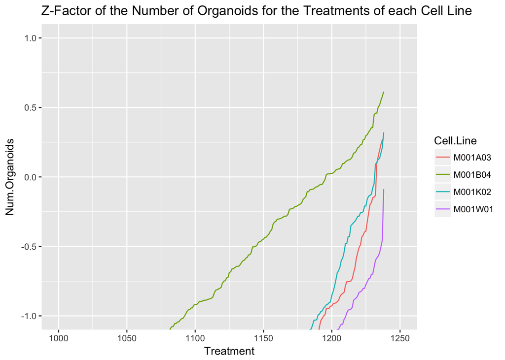

```r
ggplot(data = ggplotdf) +
  geom_line(aes(x = Treatment, y = Num.Organoids, color = Cell.Line)) +
  coord_cartesian(ylim = c(-1, 1), xlim = c(1000, 1250)) +
  ggtitle(label = "Z-Factor of the Number of Organoids for the Treatments of each Cell Line")
```

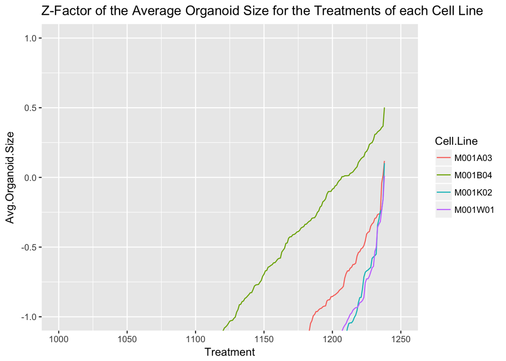

```r
ggplot(data = ggplotdf) +
  geom_line(aes(x = Treatment, y = Avg.Organoid.Size, color = Cell.Line)) +
  coord_cartesian(ylim = c(-1, 1), xlim = c(1000, 1250)) +
  ggtitle(label = "Z-Factor of the Average Organoid Size for the Treatments of each Cell Line")
```

## 2.2 Pruning Features

Features only make sense if they are sufficiently continuous. I want to discard features that are constant across the negative (DMSO) controls of a plate. A look at the ‘minimum ratio’ of unique values for each feature across plates shows that features are either continuous or constant across a plate. There is a reasonably steep transition between the two states so that the actual threshold chosen is not so important. I keep only features with more than 25% unique values across all plates.

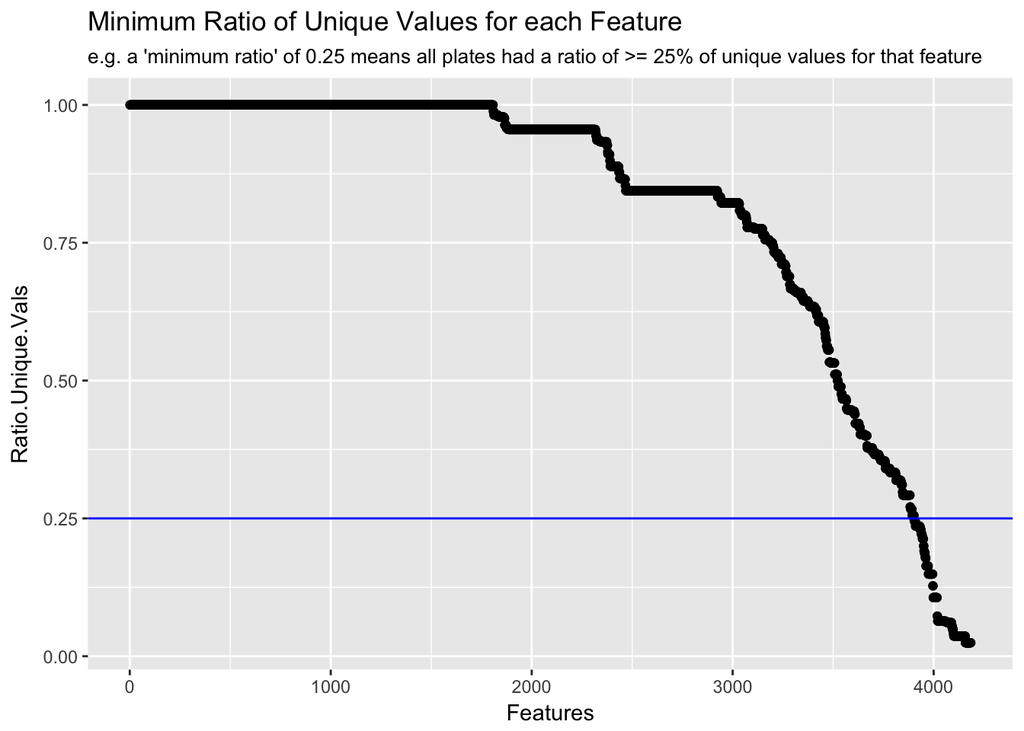

```r
neg_ctrl = features[features_metadata$DRUG == "DMSO", ]
# This rounding ensures that there are no floating point arithmetic errors that are mistaken as unique values
neg_ctrl = round(neg_ctrl, 8)
neg_ctrl_cl = substr(rownames(neg_ctrl), 1, 14)
unique_vals = aggregate(neg_ctrl, list(neg_ctrl_cl), function(x) length(unique(x)) / length(x))
rownames(unique_vals) = unique_vals$Group.1
unique_vals$Group.1 = NULL
unique_vals_min = apply(unique_vals, 2, min)
unique_vals_min_df = data.frame(
  "Ratio.Unique.Vals" = sort(unique_vals_min, decreasing = TRUE),
  "Features" = seq_along(unique_vals_min))
ggplot(data = unique_vals_min_df) + geom_point(aes(x = Features, y = Ratio.Unique.Vals)) +
  ggtitle("Minimum Ratio of Unique Values for each Feature",
          subtitle = "e.g. a 'minimum ratio' of 0.25 means all plates had a ratio of >= 25% of unique values for that feature") +
  geom_hline(aes(yintercept = 0.25), color = "blue")
```

```r
features_to_keep = names(which(unique_vals_min >= 0.25))
if(!"Total.Biomass" %in% features_to_keep)
  features_to_keep = c(features_to_keep, "Total.Biomass")
if(!"organoids_x.0.s.area_expected" %in% features_to_keep)
  features_to_keep = c(features_to_keep, "organoids_x.0.s.area_expected")
if(!"organoids_num.of.objects" %in% features_to_keep)
  features_to_keep = c(features_to_keep, "organoids_num.of.objects")
features = features[,features_to_keep]
```

## 2.3 Correlation between replicates

### 2.3.1 Cell line specfific

I look at all features now to see how well they correlate between replicates of the screen for each cell line individually

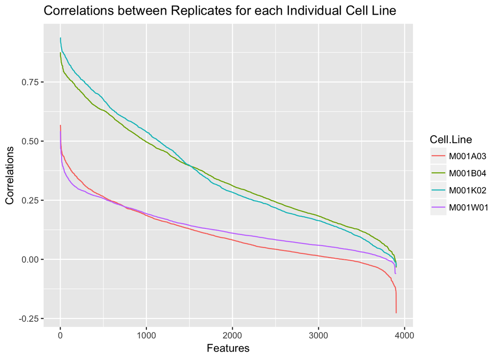

```r
cl_correlations = setNames(
  object = vector(mode = "list", length = length(cell_lines)),
  nm = cell_lines
)
for(cell_line in cell_lines) {
  cl_features = features[substr(rownames(features), 1, 7) == cell_line, ]
  cl_features_metadata = features_metadata[substr(rownames(features_metadata), 1, 7) == cell_line, ]
  rep1 = cl_features[cl_features_metadata$REPLICATE == 1, ]
  rep2 = cl_features[cl_features_metadata$REPLICATE == 2, ]
  if(!identical(paste0(substr(rownames(rep1), 1, 7), "_", substr(rownames(rep1), 12, 19)),
                paste0(substr(rownames(rep2), 1, 7), "_", substr(rownames(rep2), 12, 19)))) {
    warning(sprintf("Replicates for '%s' are not in the same order!", cell_line))
  }
  rep_correlations = setNames(
    object = vector(mode = "numeric", length = ncol(cl_features)),
    nm = colnames(cl_features))
  for(feature in colnames(cl_features)) {
    rep_correlations[[feature]] = cor(
      rep1[[feature]], rep2[[feature]],
      use = "pairwise.complete.obs")
  }
  rep_correlations = sort(rep_correlations, decreasing = TRUE)
  cl_correlations[[cell_line]] = data.frame(
    "Features" = seq_along(rep_correlations),
    "Feature.Name" = names(rep_correlations),
    "Correlations" = rep_correlations,
    "Cell.Line" = cell_line
  )
}

cl_correlations = do.call(rbind, cl_correlations)
ggplot(data = cl_correlations) + geom_line(aes(x = Features, y = Correlations, color = Cell.Line)) +
  ggtitle("Correlations between Replicates for each Individual Cell Line")
```

Cell lines M001W01 and M001A03 both show inadequate correlations. This will become a problem during the feature selection, which requires that features correlate significantly between replicates.

### 2.3.2 Screen-wide

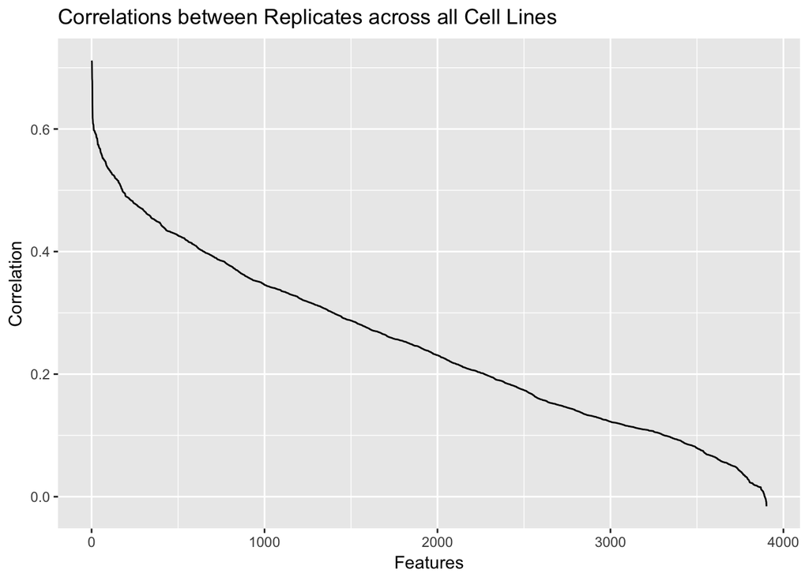

```r
rep1 = features[features_metadata$REPLICATE == 1, ]
rep2 = features[features_metadata$REPLICATE == 2, ]
if(!identical(paste0(substr(rownames(rep1), 1, 7), "_", substr(rownames(rep1), 12, 19)),
              paste0(substr(rownames(rep2), 1, 7), "_", substr(rownames(rep2), 12, 19)))) {
  warning("Replicates are not in the same order!")
}

screen_correlations = setNames(
  object = vector(mode = "numeric", length = ncol(features)),
  nm = colnames(features))
for(feature in colnames(features)) {
  screen_correlations[[feature]] = cor(
    rep1[[feature]], rep2[[feature]],
    use = "pairwise.complete.obs")
}

ggplotdf = data.frame(
  "Features" = seq_along(sort(screen_correlations)),
  "Correlation" = sort(screen_correlations, decreasing = TRUE))
ggplot(data = ggplotdf) + geom_line(aes(x = Features, y = Correlation)) +
  ggtitle("Correlations between Replicates across all Cell Lines")
```

```r
cor_thresh = 0.6
cell_line_features = cl_correlations[
  cl_correlations$Correlations >= cor_thresh &
  cl_correlations$Cell.Line %in% c("M001K02", "M001B03"),
  "Feature.Name"]
cell_line_features = names(which(table(cell_line_features) == max(table(cell_line_features))))
features_to_keep = cell_line_features
# screen_features = names(screen_correlations[screen_correlations >= cor_thresh])
# features_to_keep = intersect(screen_features, cell_line_features)

if(!"organoids_num.of.objects" %in% features_to_keep)
  features_to_keep = c(features_to_keep, "organoids_num.of.objects")
if(!"organoids_x.0.s.area_expected" %in% features_to_keep)
  features_to_keep = c(features_to_keep, "organoids_x.0.s.area_expected")
if(!"Total.Biomass" %in% features_to_keep)
  features_to_keep = c(features_to_keep, "Total.Biomass")

features = features[,features_to_keep]
features_metadata$CELL.LINE = substr(rownames(features_metadata), 1, 7)
```

# 3 Stability Selection

## 3.1 Over Entire Screen

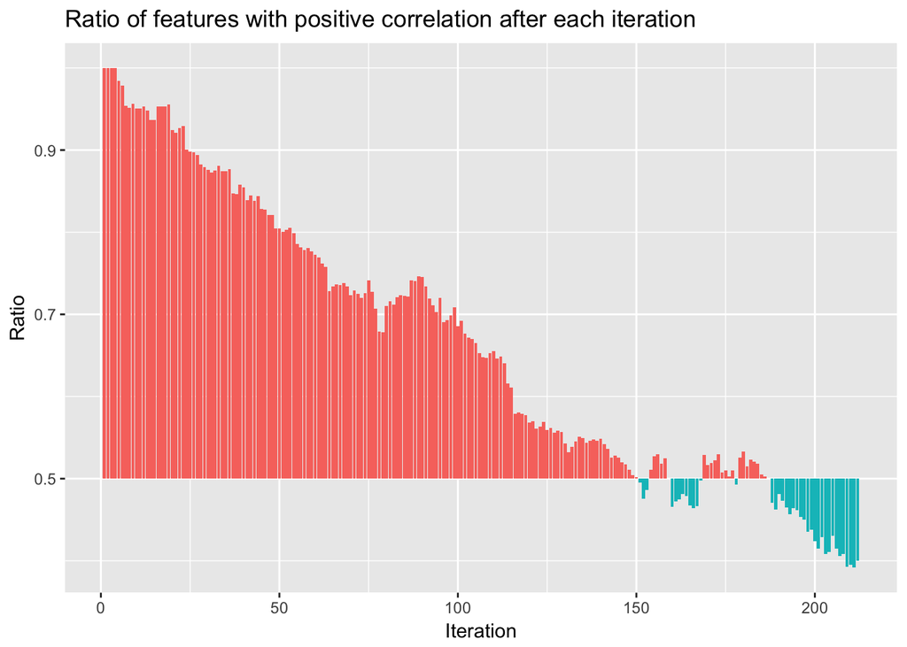

```r
# If data already exists, skip this part.
if(!file.exists("QC_mouse__stability_selection__features.rds")){
  source("../functions/StabilitySelection.R")

  # To reduce the runtime of the feature selection, I remove strongly correlating features (r >= +/-0.99).
  features_cor = cor(features, use = "pairwise.complete.obs")
  feature_cor_vector = features_cor[upper.tri(features_cor, diag = FALSE)]
  features_cor[upper.tri(features_cor, diag = TRUE)] = 0
  features_to_keep = names(which(!apply(features_cor,2,function(x) any(abs(x) > 0.99))))
  if(!"organoids_num.of.objects" %in% features_to_keep)
    features_to_keep = c(features_to_keep, "organoids_num.of.objects")
  if(!"Total.Biomass" %in% features_to_keep)
    features_to_keep = c(features_to_keep, "Total.Biomass")
  if(!"organoids_x.0.s.area_expected" %in% features_to_keep)
    features_to_keep = c(features_to_keep, "organoids_x.0.s.area_expected")
  features_reduced <- features[,features_to_keep]

  selection = selectByStability(
    features = features_reduced, metadata = features_metadata,
    preselect = c("organoids_num.of.objects", "Total.Biomass", "organoids_x.0.s.area_expected"),
    Rdim = ncol(features_reduced)-3, verbose = FALSE)

  # Keep only the selected features until the ratio drops to 0.5
  selected_features = na.omit(selection$selected[selection$ratioPositive >= 0.5])

  saveRDS(object = selection,
          file = "QC_mouse__stability_selection__results.rds")
  saveRDS(object = features[,selected_features],
          file = "QC_mouse__stability_selection__features.rds")
  saveRDS(object = features_metadata,
          file = "QC_mouse__stability_selection__features_metadata.rds")
}

ratio_positive = na.omit(readRDS("QC_mouse__stability_selection__results.rds")$ratioPositive)
ratio_color = ifelse(ratio_positive >= 0.5, "1", "2")
plot(ggplot(data = data.frame(
  "Iteration" = seq_along(ratio_positive),
  "Ratio" = ratio_positive-0.5)) +
  geom_bar(aes(x = Iteration, y = Ratio, fill = ratio_color), stat = "identity") +
  ggtitle(label = "Ratio of features with positive correlation after each iteration") +
  theme(legend.position = "none") + scale_y_continuous(labels = function(x) x+0.5))
```

## 3.2 Individually for each Cell Line

```r
source("../functions/StabilitySelection.R")
for(cell_line in cell_lines) {
  # only run this if the data doesn't exist yet
  if(file.exists(sprintf("QC_mouse__stability_selection__features_%s.rds", cell_line))) next

  features_reduced = features[features_metadata$CELL.LINE == cell_line,]
  metadata_reduced = features_metadata[features_metadata$CELL.LINE == cell_line,]

  # To reduce the runtime of the feature selection, I remove strongly correlating features (r >= +/-0.95).
  features_cor = cor(features_reduced, use = "pairwise.complete.obs")
  feature_cor_vector = features_cor[upper.tri(features_cor, diag = FALSE)]
  features_cor[upper.tri(features_cor, diag = TRUE)] = 0
  features_to_keep = names(which(!apply(features_cor,2,function(x) any(abs(x) > 0.99))))
  if(!"organoids_num.of.objects" %in% features_to_keep)
    features_to_keep = c(features_to_keep, "organoids_num.of.objects")
  if(!"Total.Biomass" %in% features_to_keep)
    features_to_keep = c(features_to_keep, "Total.Biomass")
  if(!"organoids_x.0.s.area_expected" %in% features_to_keep)
    features_to_keep = c(features_to_keep, "organoids_x.0.s.area_expected")
  features_reduced <- features_reduced[,features_to_keep]

  selection = selectByStability(
    features_reduced, metadata_reduced,
    preselect = c("organoids_num.of.objects", "Total.Biomass", "organoids_x.0.s.area_expected"),
    Rdim = ncol(features_reduced)-3, verbose = FALSE)

  # Keep only the selected features until the ratio drops to 0.5
  selected_features = na.omit(selection$selected[selection$ratioPositive >= 0.5])

  saveRDS(object = selection,
          file = sprintf("QC_mouse__stability_selection__results_%s.rds", cell_line))
  saveRDS(object = features[,selected_features],
          file = sprintf("QC_mouse__stability_selection__features_%s.rds", cell_line))
  saveRDS(object = features_metadata,
          file = sprintf("QC_mouse__stability_selection__features_metadata_%s.rds", cell_line))
}
```

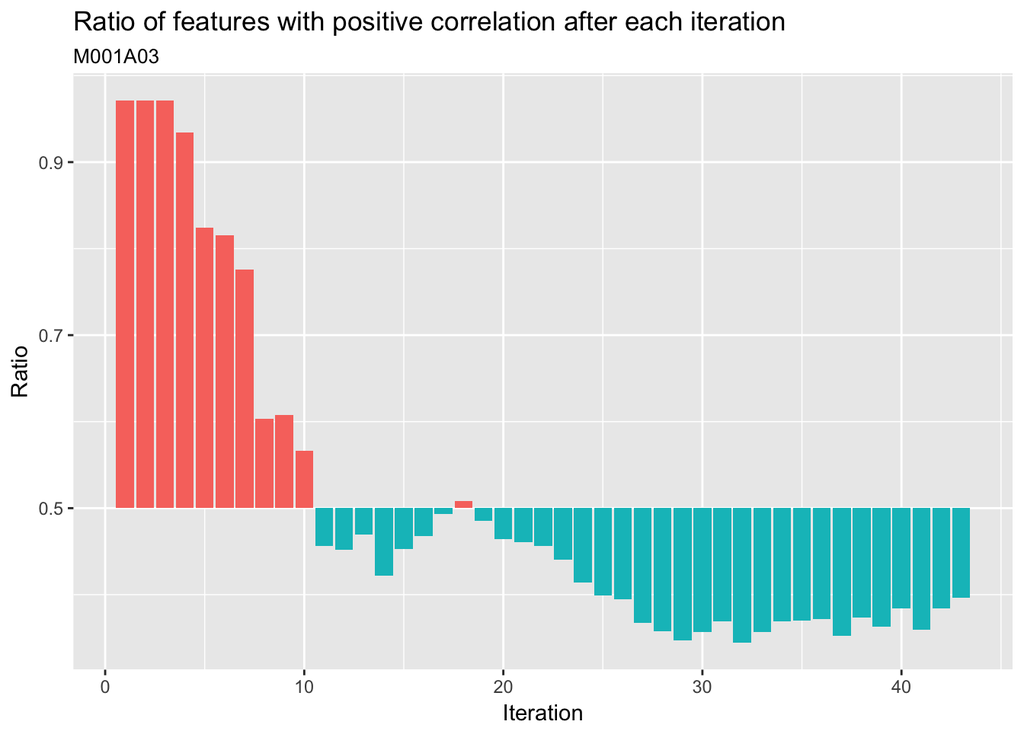

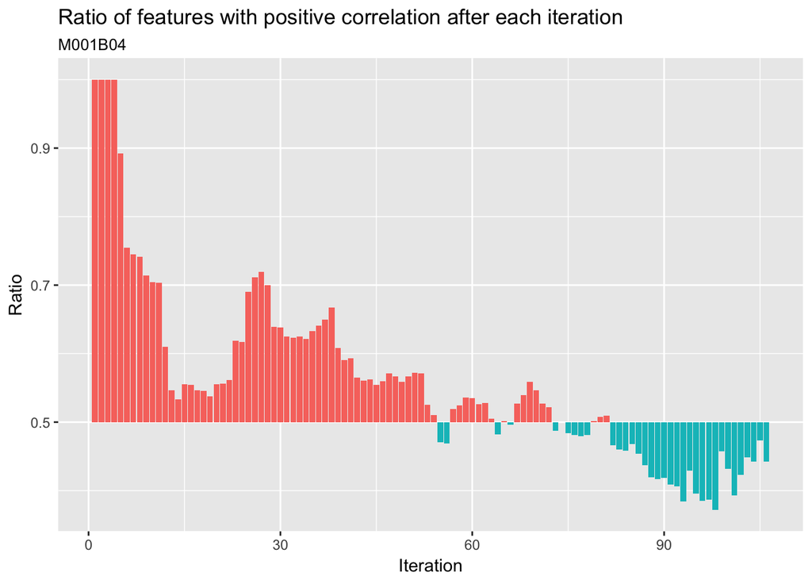

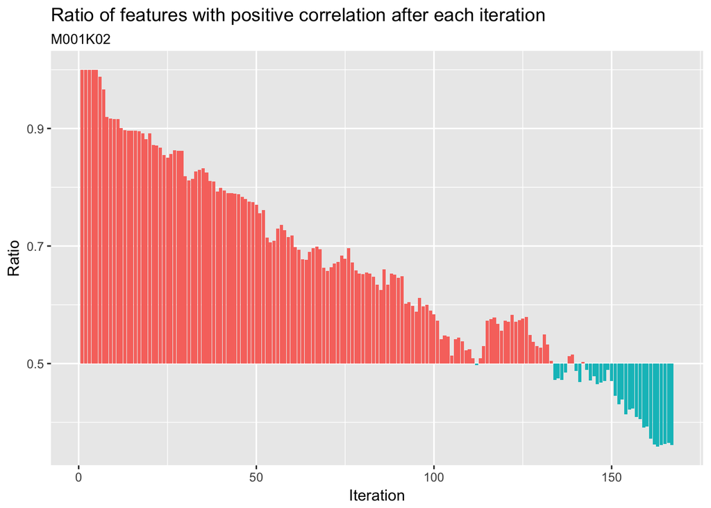

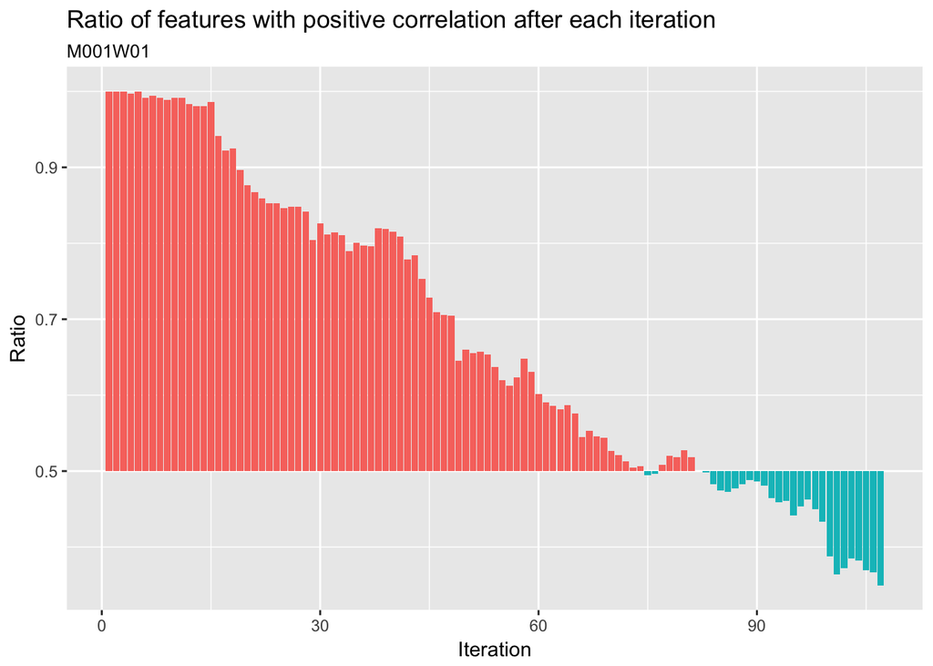

```r
for(cell_line in cell_lines) {
  ratio_positive = na.omit(readRDS(sprintf("QC_mouse__stability_selection__results_%s.rds", cell_line))$ratioPositive)
  ratio_color = ifelse(ratio_positive >= 0.5, "1", "2")
  plot(ggplot(data = data.frame(
    "Iteration" = seq_along(ratio_positive),
    "Ratio" = ratio_positive-0.5)) +
    geom_bar(aes(x = Iteration, y = Ratio, fill = ratio_color), stat = "identity") +
    ggtitle(
      label = "Ratio of features with positive correlation after each iteration",
      subtitle = cell_line) +
    theme(legend.position = "none") + scale_y_continuous(labels = function(x) x+0.5))
}
```

The overlap of selected features is

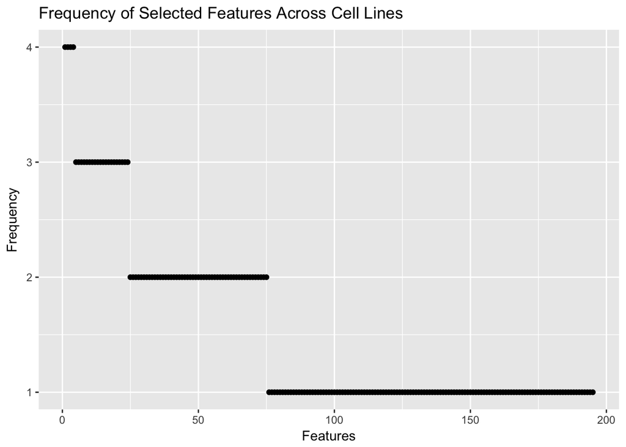

```r
selected_features = list()
for(cell_line in cell_lines) {
  selected_features[[cell_line]] = colnames(readRDS(
    sprintf("QC_mouse__stability_selection__features_%s.rds", cell_line)))
}
selected_features_freq = as.numeric(sort(table(unlist(selected_features)), decreasing = TRUE))
selected_features_freq = data.frame(
  "Features" = seq_along(selected_features_freq),
  "Frequency" = selected_features_freq)
ggplot(data = selected_features_freq) + geom_point(aes(x = Features, y = Frequency)) +
  ggtitle("Frequency of Selected Features Across Cell Lines")
```